# Abalone Project

Etana Disasa

10/29/2019

# Introduction

##### This last project for this class uses a dataset about abalons. We will use our choice of predictors to predict the age of this particular type of snail by taking several data points registered. After that, we will use a 10-fold Cross Validation to see if the predictors performed well or otherwise.

# Methods

##### The predictors I will be using are KNN and Decision Tree

## Acquiring and Exploring Data

##### I have downloaded the dataset from the intnernet and now will be using it from a local folder. The dataset does not come with a header. Given the dataset description, I have renamed the generic variable names into appropriate ones. Furthermore, I will factorize the `Rings` variable which is the age of the abalone (actually it is the ring size adding 1.5 to be exact per the description) given the predictors I will be using. Additionally, I will convert the `Sex` variable from factor to numeric for the predictors to work.

```r
MyData <- read.csv("abalone.data", header = FALSE)
names(MyData)[1:9] <- c("Sex", "Length", "Diameter", "Height", "Whole_Weight", "Shucked_Weight", "Viscera_Weight", "Shell_Weight", "Rings")
# Per the data discription, the age of a abalone is 1.5 + the rings registered. Therefore, we will have a new variable where we register the age of the abalone.
MyData$Rings <- factor(MyData$Rings)
MyData$Sex <- as.numeric(MyData$Sex)
str(MyData)
```

```
## 'data.frame':    4177 obs. of  9 variables:
##  $ Sex           : num  3 3 1 3 2 2 1 1 3 1 ...
##  $ Length        : num  0.455 0.35 0.53 0.44 0.33 0.425 0.53 0.545 0.475 0.55 ...
##  $ Diameter      : num  0.365 0.265 0.42 0.365 0.255 0.3 0.415 0.425 0.37 0.44 ...
##  $ Height        : num  0.095 0.09 0.135 0.125 0.08 0.095 0.15 0.125 0.125 0.15 ...
##  $ Whole_Weight  : num  0.514 0.226 0.677 0.516 0.205 ...
##  $ Shucked_Weight: num  0.2245 0.0995 0.2565 0.2155 0.0895 ...
##  $ Viscera_Weight: num  0.101 0.0485 0.1415 0.114 0.0395 ...
##  $ Shell_Weight  : num  0.15 0.07 0.21 0.155 0.055 0.12 0.33 0.26 0.165 0.32 ...
##  $ Rings         : Factor w/ 28 levels "1","2","3","4",..: 15 7 9 10 7 8 20 16 9 19 ...
```

### Splitting Data

```r
MySample <- sample(4177, round(4177*0.8, digits = 0))
MyTrain <- MyData[MySample, ]
MyTest <- MyData[-MySample, ]
```

#### Prediction using KNN

```r
MyPredict1 <- class::knn(MyTrain, MyTest, cl = MyTrain$Rings, k = 1)
MyActual <- MyTest$Rings
MyTable <- table(MyActual, MyPredict1)
confusionMatrix(MyTable)
```

```
## Confusion Matrix and Statistics
##
##         MyPredict1
## MyActual   1   2   3   4   5   6   7   8   9  10  11  12  13  14  15  16
##       1    0   0   0   0   0   0   0   0   0   0   0   0   0   0   0   0
##       2    0   0   1   0   0   0   0   0   0   0   0   0   0   0   0   0
##       3    0   0   3   0   0   0   0   0   0   0   0   0   0   0   0   0
##       4    0   0   0  12   0   0   0   0   0   0   0   0   0   0   0   0
##       5    0   0   0   0  15   0   0   0   0   0   0   0   0   0   0   0
##       6    0   0   0   0   0  54   0   0   0   0   0   0   0   0   0   0
##       7    0   0   0   0   0   0  79   0   0   0   0   0   0   0   0   0
##       8    0   0   0   0   0   0   0 109   0   0   0   0   0   0   0   0
##       9    0   0   0   0   0   0   0   0 146   0   0   0   0   0   0   0
##       10   0   0   0   0   0   0   0   0   0 131   0   0   0   0   0   0
##       11   0   0   0   0   0   0   0   0   0   0  89   0   0   0   0   0
##       12   0   0   0   0   0   0   0   0   0   0   0  52   0   0   0   0
##       13   0   0   0   0   0   0   0   0   0   0   0   0  44   0   0   0
##       14   0   0   0   0   0   0   0   0   0   0   0   0   0  26   0   0
##       15   0   0   0   0   0   0   0   0   0   0   0   0   0   0  15   0
##       16   0   0   0   0   0   0   0   0   0   0   0   0   0   0   0  17
##       17   0   0   0   0   0   0   0   0   0   0   0   0   0   0   0   0
##       18   0   0   0   0   0   0   0   0   0   0   0   0   0   0   0   0
##       19   0   0   0   0   0   0   0   0   0   0   0   0   0   0   0   0
##       20   0   0   0   0   0   0   0   0   0   0   0   0   0   0   0   0
##       21   0   0   0   0   0   0   0   0   0   0   0   0   0   0   0   0
##       22   0   0   0   0   0   0   0   0   0   0   0   0   0   0   0   0
##       23   0   0   0   0   0   0   0   0   0   0   0   0   0   0   0   0
##       24   0   0   0   0   0   0   0   0   0   0   0   0   0   0   0   0
##       25   0   0   0   0   0   0   0   0   0   0   0   0   0   0   0   0
##       26   0   0   0   0   0   0   0   0   0   0   0   0   0   0   0   0
##       27   0   0   0   0   0   0   0   0   0   0   0   0   0   0   0   0
##       29   0   0   0   0   0   0   0   0   0   0   0   0   0   0   0   0
##         MyPredict1
## MyActual  17  18  19  20  21  22  23  24  25  26  27  29
##       1    0   0   0   0   0   0   0   0   0   0   0   0
##       2    0   0   0   0   0   0   0   0   0   0   0   0
##       3    0   0   0   0   0   0   0   0   0   0   0   0
##       4    0   0   0   0   0   0   0   0   0   0   0   0
##       5    0   0   0   0   0   0   0   0   0   0   0   0
##       6    0   0   0   0   0   0   0   0   0   0   0   0
```

[output cut: 75 more lines]

```
## Pos Pred Value        1.000000  1.000000        NA        NA        NA
## Neg Pred Value        1.000000  1.000000        NA        NA        NA
## Prevalence            0.002395  0.002395         0         0         0
## Detection Rate        0.002395  0.002395         0         0         0
## Detection Prevalence  0.002395  0.002395         0         0         0
## Balanced Accuracy     1.000000  1.000000        NA        NA        NA
##                      Class: 27 Class: 29
## Sensitivity                 NA        NA
## Specificity                  1         1
## Pos Pred Value              NA        NA
## Neg Pred Value              NA        NA
## Prevalence                   0         0
## Detection Rate               0         0
## Detection Prevalence         0         0
## Balanced Accuracy           NA        NA
```

### Prediction Using Decision Tree

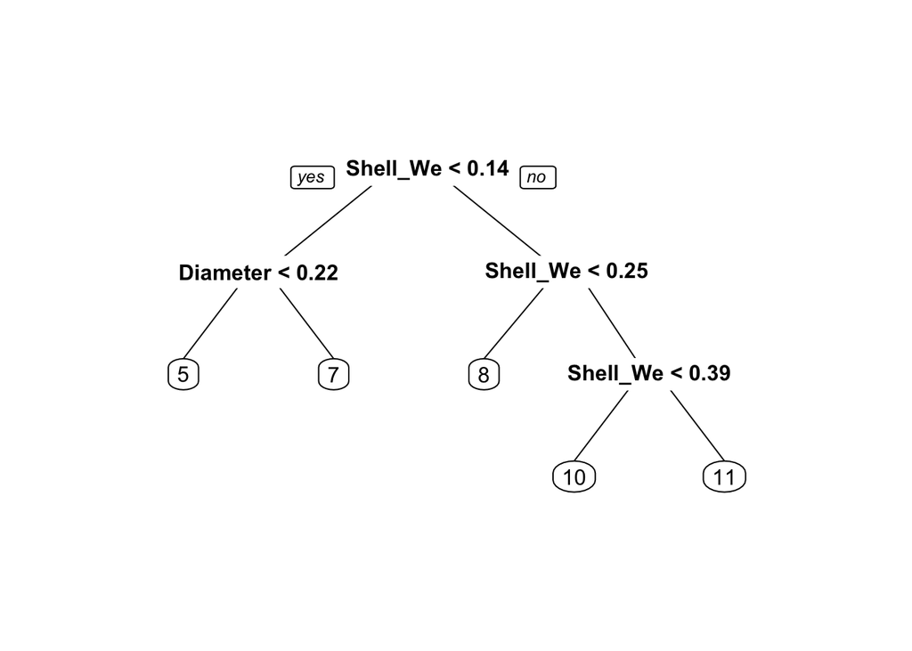

```r
MyPredict2 <- rpart(Rings~., MyTrain, method = "class")
prp(MyPredict2)
```

```r
pred <- predict(MyPredict2, MyTest, type = "class")
MyTable <- table(MyTest$Rings, pred)
MyTable
```

```
##     pred
##       1  2  3  4  5  6  7  8  9 10 11 12 13 14 15 16 17 18 19 20 21 22 23
##   1   0  0  0  0  0  0  0  0  0  0  0  0  0  0  0  0  0  0  0  0  0  0  0
##   2   0  0  0  0  1  0  0  0  0  0  0  0  0  0  0  0  0  0  0  0  0  0  0
##   3   0  0  0  0  3  0  0  0  0  0  0  0  0  0  0  0  0  0  0  0  0  0  0
##   4   0  0  0  0 11  0  1  0  0  0  0  0  0  0  0  0  0  0  0  0  0  0  0
##   5   0  0  0  0 10  0  5  0  0  0  0  0  0  0  0  0  0  0  0  0  0  0  0
##   6   0  0  0  0 14  0 36  3  0  1  0  0  0  0  0  0  0  0  0  0  0  0  0
##   7   0  0  0  0  5  0 59 13  0  2  0  0  0  0  0  0  0  0  0  0  0  0  0
##   8   0  0  0  0  0  0 39 49  0 19  2  0  0  0  0  0  0  0  0  0  0  0  0
##   9   0  0  0  0  0  0 20 70  0 52  4  0  0  0  0  0  0  0  0  0  0  0  0
##   10  0  0  0  0  0  0 12 32  0 67 20  0  0  0  0  0  0  0  0  0  0  0  0
##   11  0  0  0  0  0  0  5 20  0 39 25  0  0  0  0  0  0  0  0  0  0  0  0
##   12  0  0  0  0  0  0  2 12  0 18 20  0  0  0  0  0  0  0  0  0  0  0  0
##   13  0  0  0  0  0  0  0  5  0 24 15  0  0  0  0  0  0  0  0  0  0  0  0
```

[output cut: 45 more lines]

```r
confusionMatrix(MyTable)
```

```
## Confusion Matrix and Statistics
##
##     pred
##       1  2  3  4  5  6  7  8  9 10 11 12 13 14 15 16 17 18 19 20 21 22 23
##   1   0  0  0  0  0  0  0  0  0  0  0  0  0  0  0  0  0  0  0  0  0  0  0
##   2   0  0  0  0  1  0  0  0  0  0  0  0  0  0  0  0  0  0  0  0  0  0  0
##   3   0  0  0  0  3  0  0  0  0  0  0  0  0  0  0  0  0  0  0  0  0  0  0
##   4   0  0  0  0 11  0  1  0  0  0  0  0  0  0  0  0  0  0  0  0  0  0  0
##   5   0  0  0  0 10  0  5  0  0  0  0  0  0  0  0  0  0  0  0  0  0  0  0
##   6   0  0  0  0 14  0 36  3  0  1  0  0  0  0  0  0  0  0  0  0  0  0  0
##   7   0  0  0  0  5  0 59 13  0  2  0  0  0  0  0  0  0  0  0  0  0  0  0
##   8   0  0  0  0  0  0 39 49  0 19  2  0  0  0  0  0  0  0  0  0  0  0  0
##   9   0  0  0  0  0  0 20 70  0 52  4  0  0  0  0  0  0  0  0  0  0  0  0
##   10  0  0  0  0  0  0 12 32  0 67 20  0  0  0  0  0  0  0  0  0  0  0  0
##   11  0  0  0  0  0  0  5 20  0 39 25  0  0  0  0  0  0  0  0  0  0  0  0
##   12  0  0  0  0  0  0  2 12  0 18 20  0  0  0  0  0  0  0  0  0  0  0  0
##   13  0  0  0  0  0  0  0  5  0 24 15  0  0  0  0  0  0  0  0  0  0  0  0
##   14  0  0  0  0  0  0  1  6  0  9 10  0  0  0  0  0  0  0  0  0  0  0  0
##   15  0  0  0  0  0  0  0  6  0  5  4  0  0  0  0  0  0  0  0  0  0  0  0
##   16  0  0  0  0  0  0  1  3  0  6  7  0  0  0  0  0  0  0  0  0  0  0  0
##   17  0  0  0  0  0  0  0  2  0 11  4  0  0  0  0  0  0  0  0  0  0  0  0
##   18  0  0  0  0  0  0  1  1  0  6  2  0  0  0  0  0  0  0  0  0  0  0  0
##   19  0  0  0  0  0  0  0  0  0  2  1  0  0  0  0  0  0  0  0  0  0  0  0
##   20  0  0  0  0  0  0  0  0  0  2  5  0  0  0  0  0  0  0  0  0  0  0  0
##   21  0  0  0  0  0  0  0  0  0  0  1  0  0  0  0  0  0  0  0  0  0  0  0
##   22  0  0  0  0  0  0  0  0  0  0  2  0  0  0  0  0  0  0  0  0  0  0  0
##   23  0  0  0  0  0  0  0  0  0  0  2  0  0  0  0  0  0  0  0  0  0  0  0
##   24  0  0  0  0  0  0  0  0  0  0  0  0  0  0  0  0  0  0  0  0  0  0  0
##   25  0  0  0  0  0  0  0  0  0  0  0  0  0  0  0  0  0  0  0  0  0  0  0
##   26  0  0  0  0  0  0  0  0  0  0  0  0  0  0  0  0  0  0  0  0  0  0  0
##   27  0  0  0  0  0  0  0  0  0  0  0  0  0  0  0  0  0  0  0  0  0  0  0
##   29  0  0  0  0  0  0  0  0  0  0  0  0  0  0  0  0  0  0  0  0  0  0  0
##     pred
##      24 25 26 27 29
##   1   0  0  0  0  0
##   2   0  0  0  0  0
##   3   0  0  0  0  0
##   4   0  0  0  0  0
##   5   0  0  0  0  0
##   6   0  0  0  0  0
```

[output cut: 75 more lines]

```
## Pos Pred Value              NA        NA        NA        NA        NA
## Neg Pred Value              NA        NA        NA        NA        NA
## Prevalence            0.000000  0.000000         0         0         0
## Detection Rate        0.000000  0.000000         0         0         0
## Detection Prevalence  0.002395  0.002395         0         0         0
## Balanced Accuracy           NA        NA        NA        NA        NA
##                      Class: 27 Class: 29
## Sensitivity                 NA        NA
## Specificity                  1         1
## Pos Pred Value              NA        NA
## Neg Pred Value              NA        NA
## Prevalence                   0         0
## Detection Rate               0         0
## Detection Prevalence         0         0
## Balanced Accuracy           NA        NA
```

### 10-Fold Cross Validation of KNN Predictor

```r
# define training control
train_control <- trainControl(method="cv", number=10)
# train the model
model <- train(Rings~., data =  MyData, trControl = train_control, method = "kknn")
# summarize results
predictions <- predict(model, MyData)
confusionMatrix(MyData$Rings, predictions)
```

```
## Confusion Matrix and Statistics
##
##           Reference
## Prediction   1   2   3   4   5   6   7   8   9  10  11  12  13  14  15  16
##         1    0   0   1   0   0   0   0   0   0   0   0   0   0   0   0   0
##         2    0   0   0   1   0   0   0   0   0   0   0   0   0   0   0   0
##         3    0   0  11   3   1   0   0   0   0   0   0   0   0   0   0   0
##         4    0   0   0  48   5   3   1   0   0   0   0   0   0   0   0   0
##         5    0   0   0   5  84  18   6   1   1   0   0   0   0   0   0   0
##         6    0   0   0   1   7 207  33   7   3   0   1   0   0   0   0   0
##         7    0   0   0   1   5  25 295  34  22   6   2   1   0   0   0   0
##         8    0   0   0   0   1   9  24 462  45  17   7   1   1   1   0   0
##         9    0   0   0   0   1   5  14  37 561  39  23   6   1   1   1   0
##         10   0   0   0   0   0   3   9  17  42 531  20   8   2   0   0   2
##         11   0   0   0   0   0   1   4  15  25  26 408   5   1   1   1   0
##         12   0   0   0   0   0   0   1   8  17  17  15 204   2   0   0   0
##         13   0   0   0   0   0   0   1   7   4  24  13   3 148   0   3   0
##         14   0   0   0   0   0   0   2   2   7  10  10   3   1  89   0   0
##         15   0   0   0   0   0   0   0   4   5   8   6   1   2   0  77   0
##         16   0   0   0   0   0   0   1   0   2   3   3   0   2   2   0  54
##         17   0   0   0   0   0   0   0   0   0   3   5   2   1   0   1   1
##         18   0   0   0   0   0   0   0   1   3   5   1   2   0   0   0   2
##         19   0   0   0   0   0   0   0   0   0   2   3   1   2   0   0   0
##         20   0   0   0   0   0   0   0   0   1   2   2   0   0   0   0   0
##         21   0   0   0   0   0   0   0   0   0   1   1   0   0   0   0   0
##         22   0   0   0   0   0   0   0   0   0   0   0   1   0   0   1   0
##         23   0   0   0   0   0   0   0   0   0   0   0   0   2   0   0   0
##         24   0   0   0   0   0   0   0   0   0   0   0   0   0   0   0   0
##         25   0   0   0   0   0   0   0   0   0   0   0   0   0   0   0   0
##         26   0   0   0   0   0   0   0   0   0   1   0   0   0   0   0   0
##         27   0   0   0   0   0   0   0   0   0   0   0   0   0   0   0   0
##         29   0   0   0   0   0   0   0   0   0   0   0   0   0   0   0   0
##           Reference
## Prediction  17  18  19  20  21  22  23  24  25  26  27  29
##         1    0   0   0   0   0   0   0   0   0   0   0   0
##         2    0   0   0   0   0   0   0   0   0   0   0   0
##         3    0   0   0   0   0   0   0   0   0   0   0   0
##         4    0   0   0   0   0   0   0   0   0   0   0   0
##         5    0   0   0   0   0   0   0   0   0   0   0   0
##         6    0   0   0   0   0   0   0   0   0   0   0   0
```

[output cut: 75 more lines]

```
## Pos Pred Value        0.857143 0.5000000  0.777778 1.0000000 1.0000000
## Neg Pred Value        0.999760 1.0000000  1.000000 1.0000000 1.0000000
## Prevalence            0.003112 0.0007182  0.001676 0.0004788 0.0002394
## Detection Rate        0.002873 0.0007182  0.001676 0.0004788 0.0002394
## Detection Prevalence  0.003352 0.0014364  0.002155 0.0004788 0.0002394
## Balanced Accuracy     0.961298 0.9996406  0.999760 1.0000000 1.0000000
##                      Class: 26 Class: 27 Class: 29
## Sensitivity                 NA 1.0000000 1.0000000
## Specificity          0.9997606 1.0000000 1.0000000
## Pos Pred Value              NA 1.0000000 1.0000000
## Neg Pred Value              NA 1.0000000 1.0000000
## Prevalence           0.0000000 0.0004788 0.0002394
## Detection Rate       0.0000000 0.0004788 0.0002394
## Detection Prevalence 0.0002394 0.0004788 0.0002394
## Balanced Accuracy           NA 1.0000000 1.0000000
```

##### The above 10-fold cross validation for KNN shows that it perfromed its prediction with an approximately 80% accuracy with the given dataset. Our model with the test and train dataset perfromed much higher than that.

### 10-Fold Cross Validation of the Decision Tree

```r
# define training control
train_control <- trainControl(method="cv", number=10)
# train the model
model <- train(Rings~., data =  MyData, trControl = train_control, method = "rpart")
# summarize results
predictions <- predict(model, MyData)
confusionMatrix(MyData$Rings, predictions)
```

```
## Confusion Matrix and Statistics
##
##           Reference
## Prediction   1   2   3   4   5   6   7   8   9  10  11  12  13  14  15  16
##         1    0   0   0   0   0   0   1   0   0   0   0   0   0   0   0   0
##         2    0   0   0   0   0   0   1   0   0   0   0   0   0   0   0   0
##         3    0   0   0   0   0   0  15   0   0   0   0   0   0   0   0   0
##         4    0   0   0   0   0   0  57   0   0   0   0   0   0   0   0   0
##         5    0   0   0   0   0   0 115   0   0   0   0   0   0   0   0   0
##         6    0   0   0   0   0   0 241   0  14   4   0   0   0   0   0   0
##         7    0   0   0   0   0   0 306   0  73  12   0   0   0   0   0   0
##         8    0   0   0   0   0   0 202   0 280  86   0   0   0   0   0   0
##         9    0   0   0   0   0   0 109   0 294 286   0   0   0   0   0   0
##         10   0   0   0   0   0   0  63   0 172 399   0   0   0   0   0   0
##         11   0   0   0   0   0   0  32   0 104 351   0   0   0   0   0   0
##         12   0   0   0   0   0   0  20   0  71 176   0   0   0   0   0   0
##         13   0   0   0   0   0   0  12   0  47 144   0   0   0   0   0   0
##         14   0   0   0   0   0   0   3   0  35  88   0   0   0   0   0   0
##         15   0   0   0   0   0   0   3   0  27  73   0   0   0   0   0   0
##         16   0   0   0   0   0   0   4   0  10  53   0   0   0   0   0   0
##         17   0   0   0   0   0   0   0   0   8  50   0   0   0   0   0   0
##         18   0   0   0   0   0   0   1   0   6  35   0   0   0   0   0   0
##         19   0   0   0   0   0   0   0   0   3  29   0   0   0   0   0   0
##         20   0   0   0   0   0   0   0   0   2  24   0   0   0   0   0   0
##         21   0   0   0   0   0   0   0   0   2  12   0   0   0   0   0   0
##         22   0   0   0   0   0   0   0   0   1   5   0   0   0   0   0   0
##         23   0   0   0   0   0   0   0   0   1   8   0   0   0   0   0   0
##         24   0   0   0   0   0   0   0   0   0   2   0   0   0   0   0   0
##         25   0   0   0   0   0   0   0   0   0   1   0   0   0   0   0   0
##         26   0   0   0   0   0   0   0   0   0   1   0   0   0   0   0   0
##         27   0   0   0   0   0   0   0   0   0   2   0   0   0   0   0   0
##         29   0   0   0   0   0   0   0   0   0   1   0   0   0   0   0   0
##           Reference
## Prediction  17  18  19  20  21  22  23  24  25  26  27  29
##         1    0   0   0   0   0   0   0   0   0   0   0   0
##         2    0   0   0   0   0   0   0   0   0   0   0   0
##         3    0   0   0   0   0   0   0   0   0   0   0   0
##         4    0   0   0   0   0   0   0   0   0   0   0   0
##         5    0   0   0   0   0   0   0   0   0   0   0   0
##         6    0   0   0   0   0   0   0   0   0   0   0   0
```

[output cut: 75 more lines]

```
## Pos Pred Value              NA        NA        NA        NA        NA
## Neg Pred Value              NA        NA        NA        NA        NA
## Prevalence            0.000000  0.000000  0.000000 0.0000000 0.0000000
## Detection Rate        0.000000  0.000000  0.000000 0.0000000 0.0000000
## Detection Prevalence  0.003352  0.001436  0.002155 0.0004788 0.0002394
## Balanced Accuracy           NA        NA        NA        NA        NA
##                      Class: 26 Class: 27 Class: 29
## Sensitivity                 NA        NA        NA
## Specificity          0.9997606 0.9995212 0.9997606
## Pos Pred Value              NA        NA        NA
## Neg Pred Value              NA        NA        NA
## Prevalence           0.0000000 0.0000000 0.0000000
## Detection Rate       0.0000000 0.0000000 0.0000000
## Detection Prevalence 0.0002394 0.0004788 0.0002394
## Balanced Accuracy           NA        NA        NA
```

##### The Decision Tree predictor perfromed with a low accuracy rate not so much different from our prediction.

# Conclusion

##### This is telling that given a particular dataset, a generic model or our own application of supervised learning may yielf different results. Learning the `CARET` library’s `train` function using different code names for the known predictors/classifiers was a lot of fun. Furthermore, setting how many times the predictors/classifiers need to run the models is also a new learning process for me. In conclusion, I cannot emphasize enough how factorizing or numerizing datasets/variables is very important given what kind of predictor/classifier one is using.

# References

##### https://machinelearningmastery.com/how-to-estimate-model-accuracy-in-r-using-the-caret-package/

##### https://dataaspirant.com/2017/02/03/decision-tree-classifier-implementation-in-r/

##### https://topepo.github.io/caret/train-models-by-tag.html#Random_Forest